# R Notebook

# Confidence Interval Homework

## Q1

### Load the data again, clean_names(), and re-familiarise yourself with it

```r
library(tidyverse)
library(janitor)
```

```r
glimpse(ames)
```

```
Rows: 2,930
Columns: 82
$ order           <dbl> 1, 2, 3, 4, 5, 6, 7, 8, 9, 10, 11, 12, 13, 14, 15, 16, 17, 18, 19, 20, 21, 22, 23, 24, 25, 26, 27, 28…
$ pid             <dbl> 526301100, 526350040, 526351010, 526353030, 527105010, 527105030, 527127150, 527145080, 527146030, 52…
$ ms_sub_class    <dbl> 20, 20, 20, 20, 60, 60, 120, 120, 120, 60, 60, 20, 60, 20, 120, 60, 50, 20, 20, 20, 20, 85, 60, 20, 2…
$ ms_zoning       <chr> "RL", "RH", "RL", "RL", "RL", "RL", "RL", "RL", "RL", "RL", "RL", "RL", "RL", "RL", "RL", "RL", "RL",…
$ lot_frontage    <dbl> 141, 80, 81, 93, 74, 78, 41, 43, 39, 60, 75, NA, 63, 85, NA, 47, 152, 88, 140, 85, 105, 85, NA, NA, N…
$ lot_area        <dbl> 31770, 11622, 14267, 11160, 13830, 9978, 4920, 5005, 5389, 7500, 10000, 7980, 8402, 10176, 6820, 5350…
$ street          <chr> "Pave", "Pave", "Pave", "Pave", "Pave", "Pave", "Pave", "Pave", "Pave", "Pave", "Pave", "Pave", "Pave…
$ alley           <chr> NA, NA, NA, NA, NA, NA, NA, NA, NA, NA, NA, NA, NA, NA, NA, NA, NA, NA, NA, NA, NA, NA, NA, NA, NA, N…
$ lot_shape       <chr> "IR1", "Reg", "IR1", "Reg", "IR1", "IR1", "Reg", "IR1", "IR1", "Reg", "IR1", "IR1", "IR1", "Reg", "IR…
$ land_contour    <chr> "Lvl", "Lvl", "Lvl", "Lvl", "Lvl", "Lvl", "Lvl", "HLS", "Lvl", "Lvl", "Lvl", "Lvl", "Lvl", "Lvl", "Lv…
$ utilities       <chr> "AllPub", "AllPub", "AllPub", "AllPub", "AllPub", "AllPub", "AllPub", "AllPub", "AllPub", "AllPub", "…
$ lot_config      <chr> "Corner", "Inside", "Corner", "Corner", "Inside", "Inside", "Inside", "Inside", "Inside", "Inside", "…
$ land_slope      <chr> "Gtl", "Gtl", "Gtl", "Gtl", "Gtl", "Gtl", "Gtl", "Gtl", "Gtl", "Gtl", "Gtl", "Gtl", "Gtl", "Gtl", "Gt…
```

[output cut: 69 more lines]

## Q2

### Investigate the distribution of lot_area. Is the distribution roughly normal? If not, what problems do you find?

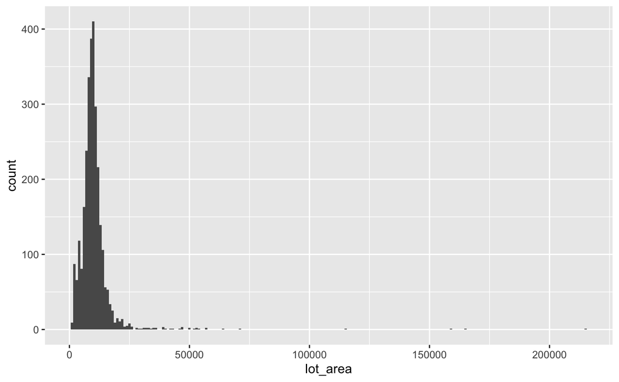

## Q3

### Compute and visualise a bootstrap sampling distribution for the mean(lot_area) of the sold houses.

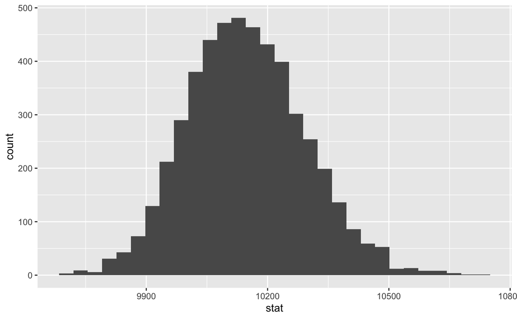

```r
bootstrap_sample %>%
  ggplot(aes(x = stat)) +
  geom_histogram()
```

## Q4

### Use your bootstrap distribution to calculate a 95% CI for mean(lot_area), and visualise it on the distribution

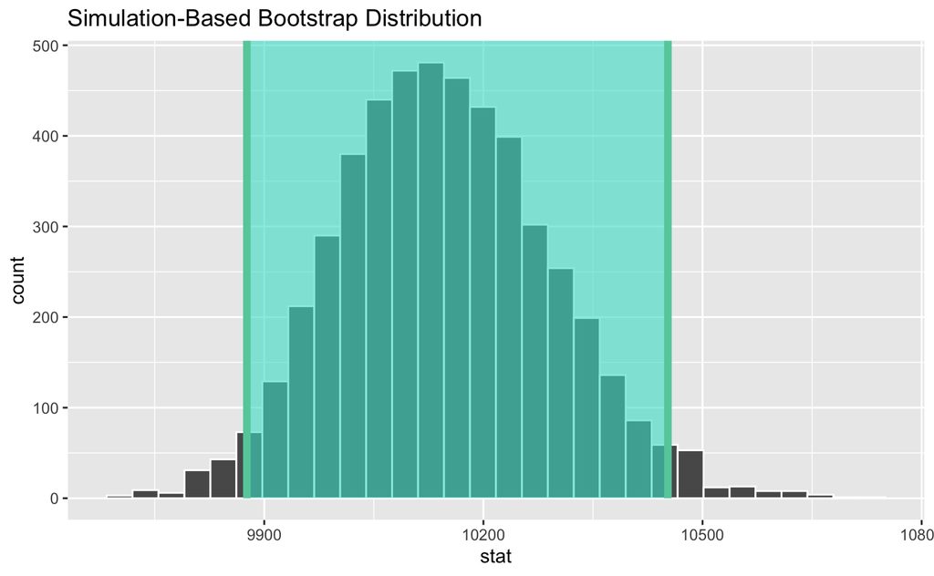

## Q5

### You would like to know the mean(lot_area) of the sold houses with higher confidence. Calculate the 99%

CI for this variable (you can re-use your bootstrap distribution from above). Is it narrower or broader than the 95% CI? Does that make sense?

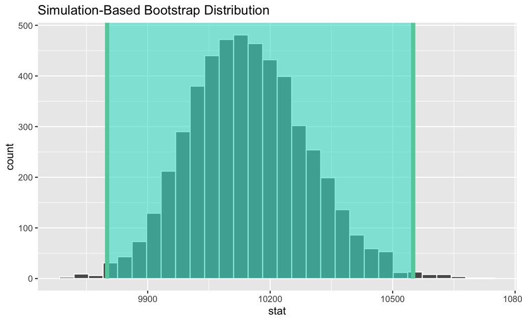

> they’re wider (as I suspected) because they’re capturing a higher percentage of the data points

## Q6 ### Calculate the point estimate of the mean(lot_area)

| mean |
| --- |
| 10147.33 |

# 2 Extension

## Task 1.

### Calculate a point estimate and 95% CI for the proportion of houses in the data built before 1920. Does the number of reps you use matter? [Investigate reps from 200 up to 50000, memory of your laptop permitting].

| prop_before_1920 |
| --- |
| 0.06006826 |

200 reps

```r
bootstrap_prop_200 <- before_1920 %>%
  specify(response = before_1920, success = "Yes") %>%
  generate(reps = 200, type = "bootstrap") %>%
  calculate(stat = "prop")

ci_95_200 <- bootstrap_prop_200 %>%
  get_ci(level = 0.95, type = "percentile")

ci_95_200
```

| lower_ci | upper_ci |
| --- | --- |
| 0.05083618 | 0.06894198 |

```r
p_est_200 <- bootstrap_prop_200 %>%
  summarise(mean = mean(stat))

p_est_200
```

| mean |
| --- |
| 0.05972867 |

500 reps

```r
bootstrap_prop_500 <- before_1920 %>%
  specify(response = before_1920, success = "Yes") %>%
  generate(reps = 500, type = "bootstrap") %>%
  calculate(stat = "prop")

ci_95_500 <- bootstrap_prop_500 %>%
  get_ci(level = 0.95, type = "percentile")

ci_95_500
```

| lower_ci | upper_ci |
| --- | --- |
| 0.05085324 | 0.06825939 |

```r
p_est_500 <- bootstrap_prop_500 %>%
  summarise(mean = mean(stat))

p_est_500
```

| mean |
| --- |
| 0.05952833 |

1000 reps

```r
bootstrap_prop_1000 <- before_1920 %>%
  specify(response = before_1920, success = "Yes") %>%
  generate(reps = 1000, type = "bootstrap") %>%
  calculate(stat = "prop")

ci_95_1000 <- bootstrap_prop_1000 %>%
  get_ci(level = 0.95, type = "percentile")

ci_95_1000
```

| lower_ci | upper_ci |
| --- | --- |
| 0.0515273 | 0.06928328 |

```r
p_est_1000 <- bootstrap_prop_1000 %>%
  summarise(mean = mean(stat))

p_est_1000
```

| mean |
| --- |
| 0.06023003 |

2000 reps

```r
bootstrap_prop_2000 <- before_1920 %>%
  specify(response = before_1920, success = "Yes") %>%
  generate(reps = 2000, type = "bootstrap") %>%
  calculate(stat = "prop")

ci_95_2000 <- bootstrap_prop_2000 %>%
  get_ci(level = 0.95, type = "percentile")

ci_95_2000
```

| lower_ci | upper_ci |
| --- | --- |
| 0.05187713 | 0.06894198 |

```r
p_est_2000 <- bootstrap_prop_2000 %>%
  summarise(mean = mean(stat))

p_est_2000
```

| mean |
| --- |
| 0.06012389 |

5000 reps

```r
bootstrap_prop_5000 <- before_1920 %>%
  specify(response = before_1920, success = "Yes") %>%
  generate(reps = 5000, type = "bootstrap") %>%
  calculate(stat = "prop")

ci_95_5000 <- bootstrap_prop_5000 %>%
  get_ci(level = 0.95, type = "percentile")

ci_95_5000
```

| lower_ci | upper_ci |
| --- | --- |
| 0.05153584 | 0.06928328 |

```r
p_est_5000 <- bootstrap_prop_5000 %>%
  summarise(mean = mean(stat))

p_est_5000
```

| mean |
| --- |
| 0.06008328 |